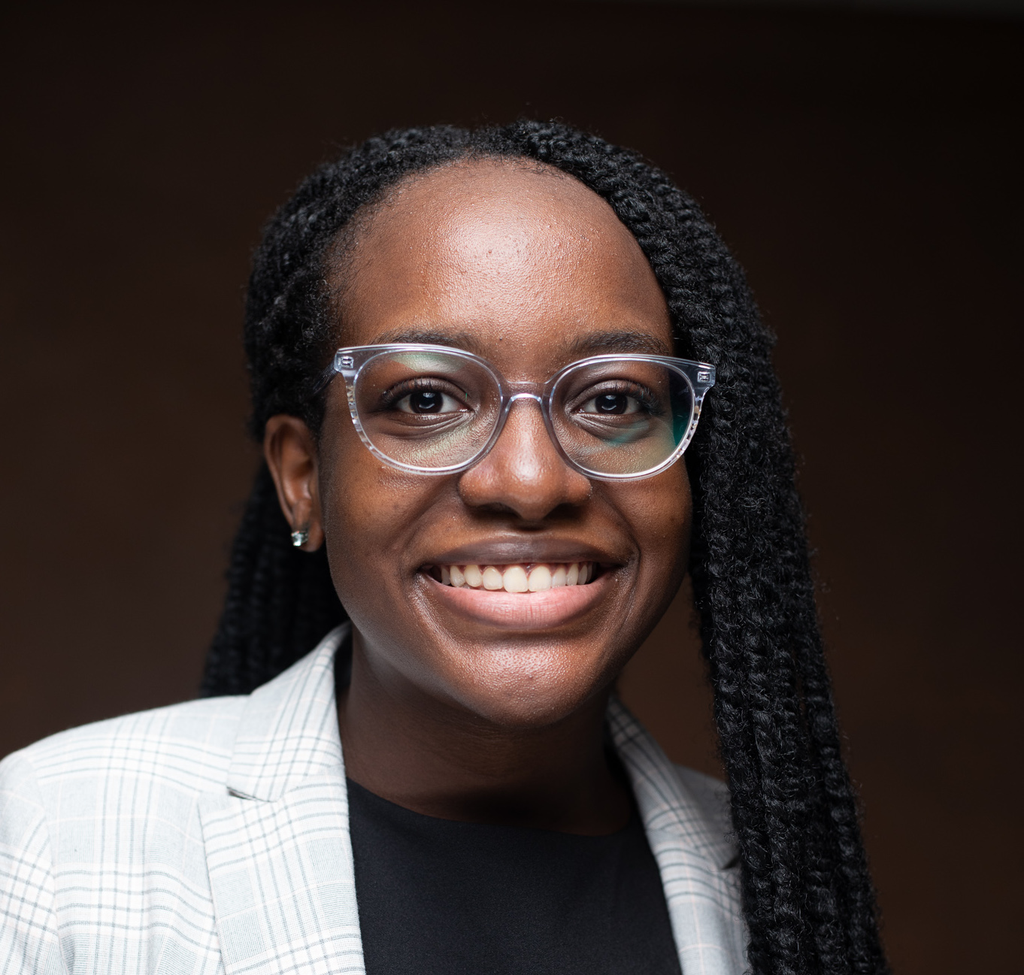

# Tamisha Dzifa Segbefia

## Bio

I’m Tamisha, a passionate advocate for fairness, a relentless hard-worker, and a lifelong learner. My journey in the world of biomedical engineering, paired with my background in Computer Engineering, has led me to a groundbreaking research path where I’m committed to eliminating biases in computational medicine. My goal is to ensure that the medical and clinical algorithms we rely on are not only accurate but also equitable.

I’m driven by a deep-seated desire to increase representation, particularly for Black women, in the STEM and healthcare sectors. Beyond academia, I’m actively involved in volunteer work, including serving my church community and collaborating with organizations like Black Sisters in STEM.

In my downtime, I unleash my creative side through digital illustration and the graceful art of calligraphy. I’m also a proud blogger, sharing insights and experiences from my unique perspective.

Thank you for stopping by my corner of the web, where I’m excited to share my research journey, experiences, and a slice of my vibrant life.

## Education

**The Johns Hopkins University** | Baltimore, MD

MSE in Biomedical Engineering | August 2022 - Present

**Ashesi University** | Berekuso, GH

B.S. in Computer Engineering | September 2017 - June 2021

## Experience

**Translational Informatics and Research Insights (TIRI) Lab** | Master’s Thesis Researcher | August 2022 - Present

**Ashesi University** | Scholarship of Teaching & Learning (SoTL) Research Assistant | August 2021 - July 2022